# Analyzing Spotify Extended Streaming History

Daniel Araujo

Date of data request: January 23rd, 2024

## Introduction

I learned that, if requested, Spotify sends users their extended streaming history data. Since I’m excited about data science, of course I had to do it. My idea with this script is to slowly write code over time, as I have spare time, to analyze my data. Additionally, I plan on periodically request my streaming data.

In case you’d like to try it for yourself, feel free to request your own extended streaming data and copy any chunks of code I wrote. As a disclaimer, I’m not trying to code the most efficient way in here. It’s just supposed to be fun. Don’t judge my code!

## 1. Reading input files

The data are in multiple *.json* files with the same prefix. So, first I read the files and merged them into a single data frame, and then removed unnecessary columns.

```r
library(jsonlite)
library(tidyverse)
library(viridis)
library(treemapify)
library(ggrepel)
'%&%' = function(a,b) paste (a,b,sep='')

# list of subfiles to read
list_of_json_files <- list.files(path='SpotifyAccountData/', pattern='Streaming_History_Audio')

# read each file and append to a merged data frame
for (f in list_of_json_files){
  tmp <- fromJSON(readLines('SpotifyAccountData/'%&% f))
  if (exists('full_df')){
    full_df <- rbind(full_df, tmp)
    rm(tmp)
  } else { full_df <- tmp }
}

# only keep columns I want
full_df <- full_df %>% select(master_metadata_album_artist_name, master_metadata_album_album_name, master_metadata_track_name, ts, ms_played) %>% drop_na()

# make sure the timestamp column is in the correct format
full_df$ts <- as_datetime(full_df$ts)

# renaming first two columns (names are too big!)
colnames(full_df)[1:3] <- c('artist_name','album_name','track_name')
```

## 2. Skipped songs

The original data contains a ‘skipped’ column with Boolean values, however most cells were empty. Thus, I decided to implement my own ‘Did I skip this song?’ algorithm, which basically is: if I listened to a song for less than 10 seconds, it’s considered as skipped.

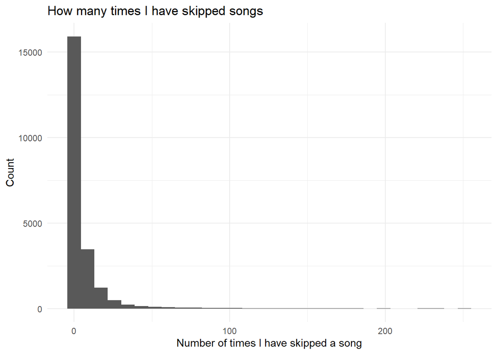

```r
# keeps songs that I listened to for less than 10 seconds
songs_skipped <- full_df %>% filter(ms_played<=9999)

# analyze how much I've skipped songs
songs_skipped_summary <- songs_skipped %>% group_by(track_name, artist_name) %>%
  summarise(times_skipped=n()) %>% unique()

# plot a histogram
ggplot(songs_skipped_summary, aes(x=times_skipped)) + geom_histogram() +
  xlab('Number of times I have skipped a song') + ylab('Count') +
  ggtitle('How many times I have skipped songs') + theme_minimal()
```

As we can see, most songs I have skipped few times. Those are probably songs Spotify recommended to me once or twice, and I skipped them. However, there are songs I have skipped a lot! Let’s see the top 10 most skipped songs of all time:

```r
# 10 most skipped songs of all time
songs_skipped_summary %>% arrange(desc(times_skipped)) %>% head(n=10)
```

```
## # A tibble: 10 x 3
## # Groups:   track_name [10]
##    track_name               artist_name       times_skipped
##    <chr>                    <chr>                     <int>
##  1 Daddy Issues             The Neighbourhood           252
##  2 Sweater Weather          The Neighbourhood           230
##  3 Bubblegum Bitch          MARINA                      229
##  4 How to Be a Heartbreaker MARINA                      197
##  5 American Money           BÃ˜RNS                      186
##  6 Hypnotic                 Zella Day                   183
##  7 Crier tout bas           CÅ“ur De Pirate             182
##  8 Place de la RÃ©publique  CÅ“ur De Pirate             170
##  9 Primadonna               MARINA                      168
## 10 I'll Be Good             Jaymes Young                167
```

Bingo! Those are songs I definitely enjoy, but sometimes I just don’t wanna listen to them.

## 3. Most streamed songs

OK, so now that I was able to briefly analyze the data corresponding to my skipped songs, let’s take a look at the ones I actually listened to. First, let’s see my top 100 most streamed songs of all my time as a Spotify user.

```r
# keeps songs that I listened to for at least 10 seconds
songs_listened <- full_df %>% filter(ms_played>=10000)

# analyze how much I've streamed songs
songs_listened_summary <- songs_listened %>% group_by(track_name, artist_name) %>%
  summarise(times_streamed=n()) %>% unique()

# 100 most streamed songs of all time
songs_listened_summary %>% arrange(desc(times_streamed)) %>% print(n=100)
```

```
## # A tibble: 15,657 x 3
## # Groups:   track_name [14,294]
##     track_name                                       artist_name  times_streamed
##     <chr>                                            <chr>                 <int>
##   1 American Money                                   BÃ˜RNS                  432
##   2 Mariners Apartment Complex                       Lana Del Rey            406
##   3 Crier tout bas                                   CÅ“ur De Pi~            389
##   4 Daddy Issues                                     The Neighbo~            379
##   5 Moondust                                         Jaymes Young            362
##   6 Sweater Weather                                  The Neighbo~            320
##   7 Hypnotic                                         Zella Day               316
##   8 Ultraviolence                                    Lana Del Rey            310
##   9 The Emotion                                      BÃ˜RNS                  309
##  10 Place de la RÃ©publique                          CÅ“ur De Pi~            308
##  11 Liability                                        Lorde                   286
```

[output cut: 90 more lines]

I feel like any comment about my top 100 list would be TMI. It is what it is.

Now, let’s see the top 10 songs per year.

```r
# sum amount of times I've streamed each song per year
songs_listened_summary <- songs_listened %>% group_by(track_name, artist_name, year(ts)) %>%
  summarise(times_streamed=n()) %>% unique()

# rename "year(ts)" column
colnames(songs_listened_summary)[3] <- c('year')

# get top 10 per year
top10songs_listened <- songs_listened_summary %>% group_by(year) %>% arrange(desc(times_streamed)) %>%
  slice(1:10)

# print full data frame
top10songs_listened %>% arrange(desc(times_streamed)) %>% print(n=nrow(top10songs_listened))
```

```
## # A tibble: 87 x 4
## # Groups:   year [10]
##    track_name                                   artist_name  year times_streamed
##    <chr>                                        <chr>       <dbl>          <int>
##  1 American Money                               BÃ˜RNS       2022            177
##  2 J'suis pas dupe                              Pomme        2020            168
##  3 Icy                                          Kim Petras   2022            166
##  4 Crier tout bas                               CÅ“ur De P~  2020            163
##  5 Comment je vais faire                        Hoshi        2020            149
##  6 Mini World                                   Indila       2020            145
##  7 DerniÃ¨re danse                              Indila       2020            140
##  8 Moondust                                     Jaymes You~  2022            130
##  9 Avenir                                       Louane       2020            129
## 10 Sur la lune                                  Bigflo & O~  2020            129
## 11 THE QUIET                                    Troye Sivan  2022            128
```

[output cut: 76 more lines]

It is interesting to see my top 10 songs of each year, because I definitely see how it changes over the years. It is also possible to notice that I basically did not use Spotify between 2015-2017, so I will make sure to remove those years from my data frame.

```r
# only keep streams that occurred in 2018 or after
songs_listened <- songs_listened %>% filter(year(ts)>2017)
```

## 4. Favorite artists

Now, what are the artists I listen to the most? I have my own guesses, but let’s see what the data tell us.

```r
# get the total amount of times I've listened to each artist
artists_frequency <- songs_listened %>% group_by(artist_name) %>%
  summarise(times_listened=n())

# print the top 100
artists_frequency %>% arrange(desc(times_listened)) %>% print(n=100)
```

```
## # A tibble: 4,145 x 2
##     artist_name              times_listened
##     <chr>                             <int>
##   1 Lana Del Rey                       9547
##   2 All Time Low                       4231
##   3 MARINA                             3738
##   4 Paramore                           3428
##   5 Taylor Swift                       3171
##   6 The Neighbourhood                  3008
##   7 Jaymes Young                       2612
##   8 Melanie Martinez                   2585
##   9 Fall Out Boy                       2469
##  10 Barcelona                          2442
##  11 Britney Spears                     2398
##  12 BÃ˜RNS                             2314
```

[output cut: 89 more lines]

Am I surprised Lana Del Rey is in the first place? No. Am I shocked by the difference between her and the second place? A bit. But overall, the top 100 fairly represents my musical taste (duh!).

Let’s do top 10 per year now.

```r
# get the total amount of times I've listened to each artist per year
artists_frequency <- songs_listened %>% group_by(artist_name, year(ts)) %>%
  summarise(times_listened=n())

# rename "year(ts)" column
colnames(artists_frequency)[2] <- c('year')

# get top 10 per year
top10artists_listened <- artists_frequency %>% group_by(year) %>% arrange(desc(times_listened)) %>%
  slice(1:10)

# print full data frame
top10artists_listened %>% arrange(desc(times_listened)) %>% print(n=nrow(top10artists_listened))
```

```
## # A tibble: 70 x 3
## # Groups:   year [7]
##    artist_name             year times_listened
##    <chr>                  <dbl>          <int>
##  1 Lana Del Rey            2023           2622
##  2 Lana Del Rey            2022           2243
##  3 Lana Del Rey            2019           1553
##  4 All Time Low            2019           1472
##  5 Jaymes Young            2020           1448
##  6 All Time Low            2020           1446
##  7 Lana Del Rey            2021           1324
##  8 Barcelona               2020           1291
##  9 Taylor Swift            2023           1251
## 10 Melanie Martinez        2019           1228
## 11 The Cab                 2020           1227
```

[output cut: 59 more lines]

I feel like the breakdown per year does not have as much information as the previous one, but it is possible to see how in some years I was more into certain music genres than others.

Just out of curiosity, I would like to know how often the same artists are found within my top 10 across all years.

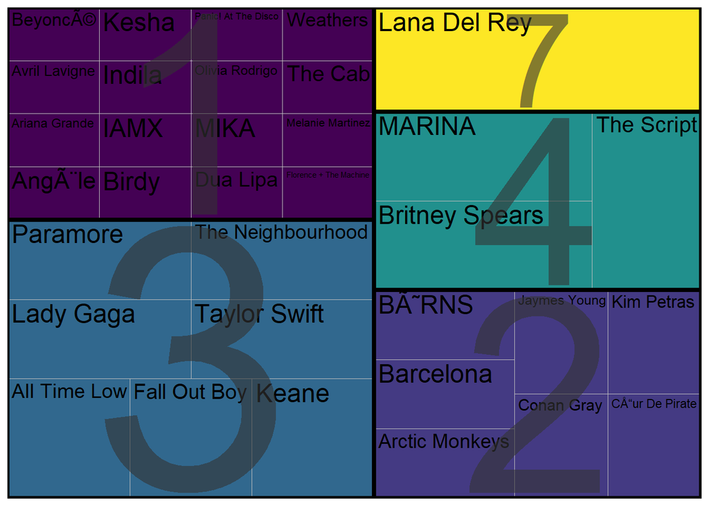

```r
# count how many times an artist appears in a top 10
top10artists_frequency <- top10artists_listened %>% group_by(artist_name) %>% summarise(times_in_top10=n())

# make a treemap
ggplot(top10artists_frequency, aes(area=times_in_top10, fill=times_in_top10, label=artist_name, subgroup=times_in_top10)) + labs(fill='Artist') + geom_treemap() + geom_treemap_text() + geom_treemap_subgroup_border(color='black') + geom_treemap_subgroup_text(place='centre', grow=T, alpha=0.6) + theme(legend.position='none') + scale_fill_viridis()
```

In the treemap above, gray numbers represent how many times the artists in each subgroup (same color) are found in a top 10. Lana Del Rey is the only artist that has appeared in a top 10 every year. No surprises there.

## 5. Favorite albums

Now, let’s see what are my most streamed albums. To do this, I will group by both album name and artist name, as there could be albums released by different authors that might have the same name.

```r
# get the total amount of times I've listened to each album
album_frequency <- songs_listened %>% group_by(album_name, artist_name) %>%
  summarise(times_listened=n())

# print the top 100
album_frequency %>% arrange(desc(times_listened)) %>% print(n=100)
```

```
## # A tibble: 9,680 x 3
## # Groups:   album_name [8,912]
##     album_name                                        artist_name times_listened
##     <chr>                                             <chr>                <int>
##   1 Born To Die - The Paradise Edition                Lana Del R~           1928
##   2 Norman Fucking Rockwell!                          Lana Del R~           1875
##   3 K-12                                              Melanie Ma~           1808
##   4 Dopamine                                          BÃ˜RNS                1753
##   5 Ultraviolence                                     Lana Del R~           1343
##   6 Future Nostalgia                                  Dua Lipa              1209
##   7 Mini World                                        Indila                1209
##   8 Chemtrails Over The Country Club                  Lana Del R~           1160
##   9 Lust For Life                                     Lana Del R~           1018
##  10 AM                                                Arctic Mon~            997
##  11 Electra Heart                                     MARINA                 942
```

[output cut: 90 more lines]

To be honest, I did not expect to see some albums on my top 10 so high on this list!

## 6. Artist revenue

Contrary to what most people believe, Spotify does not pay artist royalties according to a per-play or per-stream rate. It is more complicated than that. However… what if they did? According to a totally not in-depth and scientific research I did, most artists are paid roughly 0.004 USD per stream. So using a little bit of math, let’s see how much money artists have made from my streams alone.

```r
# get the total amount of times I've listened to each artist and multiply by the "payment rate"
artists_revenue <- songs_listened %>% group_by(artist_name) %>%
  summarise(revenue=n()*0.004)

# print the top 100
artists_revenue %>% arrange(desc(revenue)) %>% print(n=100)
```

```
## # A tibble: 4,145 x 2
##     artist_name              revenue
##     <chr>                      <dbl>
##   1 Lana Del Rey               38.2
##   2 All Time Low               16.9
##   3 MARINA                     15.0
##   4 Paramore                   13.7
##   5 Taylor Swift               12.7
##   6 The Neighbourhood          12.0
##   7 Jaymes Young               10.4
##   8 Melanie Martinez           10.3
##   9 Fall Out Boy                9.88
##  10 Barcelona                   9.77
##  11 Britney Spears              9.59
##  12 BÃ˜RNS                      9.26
```

[output cut: 89 more lines]

This result honestly made me laugh. The revenue values are very low. However, I am just one person, right? Given the huge amount of Spotify users, artists make much more money than that. Additionally, they have other sources of income as well.

## 7. Time spent listening to music

For this section, I would like to know how many days per year I spent listening to music.

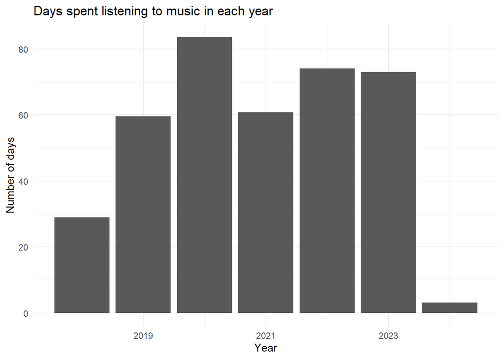

```r
# make a 'days_played' column based on the 'ms_played' column
# 1 millisecond = 1.15741e-8 days
songs_listened <- songs_listened %>% mutate(days_played=ms_played*1.15741e-8)

# for every year, sum the days_played column
time_spent_w_songs <- songs_listened %>% group_by(year(ts)) %>% summarise(days_listened=sum(days_played))

# rename "year(ts)" column
colnames(time_spent_w_songs)[1] <- c('year')

# let's plot it!
ggplot(time_spent_w_songs, aes(x=year, y=days_listened)) + geom_col() +
  xlab('Year') + ylab('Number of days') + ggtitle('Days spent listening to music in each year') + theme_minimal()
```

So many days listening to music in 2020! I blame COVID-19.

## 8. Time spent streaming certain artists

Now that we know how many days per year I have spent streaming songs, let’s do something similar but now with the artists in my top 10 overall.

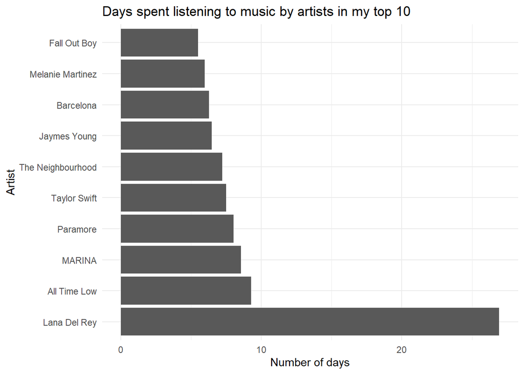

```r
# get the names of the artists in my top 10
top10artists <- songs_listened %>% group_by(artist_name) %>%
  summarise(times_listened=n()) %>% arrange(desc(times_listened)) %>%
  slice(1:10) %>% pull(artist_name)

# filter main data frame so it only contains artists in my top 10
top10artists_streamingtime <- songs_listened %>% filter(artist_name %in% top10artists)

# compute total streaming time
top10artists_streamingtime <- top10artists_streamingtime %>% group_by(artist_name) %>%
  summarise(streaming_time=sum(days_played))

# plot
ggplot(top10artists_streamingtime, aes(x=reorder(artist_name, -streaming_time), y=streaming_time)) +
  geom_col() + coord_flip() + xlab('Artist') + ylab('Number of days') +
  ggtitle('Days spent listening to music by artists in my top 10') + theme_minimal()
```

I must admit, that is a lot of days listening to Lana Del Rey. But the results look so good visualized this way!

## 9. Favorite artists per week

I wanna try and plot what were my top artists per week, across all my years as a Spotify user. What I hope to see is how my most listened to artists per week change according to some life events, such as concerts, plays, new album releases, etc.

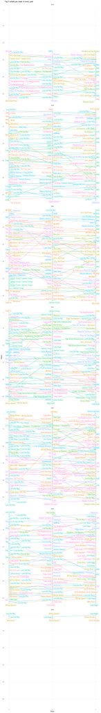

```r
# for every year and week, sum the time spent listening to every artist
topartists_week <- songs_listened %>% group_by(year(ts), week(ts), artist_name) %>% summarise(time=sum(ms_played))

# rename lubridate-made columns
colnames(topartists_week)[1:2] <- c('year', 'week')

# for every year and week, select the top 3 artists and add a new column with their respective position in the top 3
topartists_week <- topartists_week %>% group_by(year, week) %>% slice_max(time, n=3) %>% mutate(position=c(1:3))

# plot it!
ggplot(topartists_week, aes(x=week, y=position, color=artist_name, label=artist_name)) + geom_point(show.legend=F) + geom_line(show.legend=F) + geom_label_repel(show.legend=F) + facet_wrap(~year, ncol=1) + scale_y_continuous(breaks=c(1,2,3)) + scale_x_reverse(breaks=c(1,10,20,30,40,50)) + coord_flip() + xlab('Week') + ylab('Rank') + ggtitle('Top 3 artists per week in every year') + theme_minimal()
```

Ok… this isn’t my most beautiful work. The plot is too busy, but I don’t think I could improve it further. Anyway, regardless of how busy the figure is, it’s still possible to draw some information from it. For instance, we can see the influence in my top artists of the week in weeks in which I saw some musicals in the theater (such as SIX on May 10th, 2022), an artist released a new album (for example, Dua Lipa’s Future Nostalgia on March 27th, 2020 and Beyoncé’s Renaissance on July 29th, 2022), or I first discovered an artist for the first time and streamed them a bunch (such as Weathers on September 6th-12th).

Overall, the plot tells an interesting story. But to be fair, this plot is probably only that interesting to me.